# How does ML work? 머신 러닝의 학습 원리

### what is the basic idea of machine learning / 머신 러닝의 기본적인 학습 원리

```python
import numpy as np
import pandas as pd
import matplotlib.pyplot as plt
%matplotlib inline
%config InlineBackend.figure_format = 'retina'
```

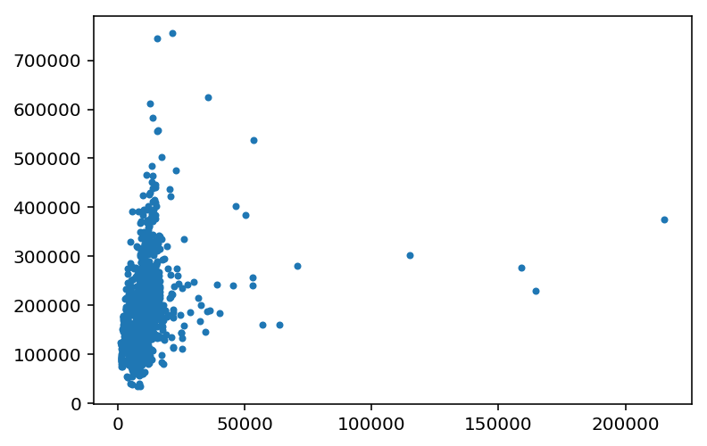

```python
# load, and quick check data
house_price = pd.read_csv('data/house_price_train.csv')
house_price = house_price[['LotArea', 'SalePrice']]

plt.plot(house_price['LotArea'], house_price['SalePrice'], '.')
```

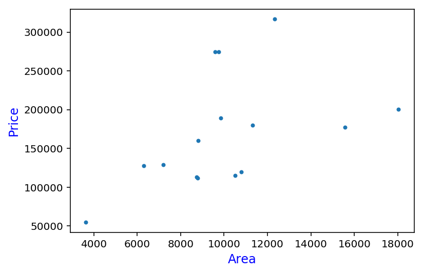

```python
# To make it easier to understand, I pull out 15 random houses,
# we will use these house only for this post
sample_data = house_price.sample(15, random_state=3)
plt.plot(sample_data['LotArea'], sample_data['SalePrice'], '.')
plt.xlabel('Area', fontsize=12, color='blue')
plt.ylabel('Price', fontsize=12, color='blue')
```

```python
# Simple function to draw lien
def graph(formula, x_range):
    x = np.array(x_range)
    y = eval(formula)
    plt.plot(x, y)
```

## 아래 세가지 색깔의 선은 서로 다른 예측 모델을 의미합니다.

우리는 본능적으로 초록선이 자료를 예측하는데 가장 적합하다는 것을 알 수 있습니다. 하지만, 우리가 '본능적'으로 생각하는 사이 우리는 어떠한 과정을 통해 이러한 결론을 낼 수 있었을까요?

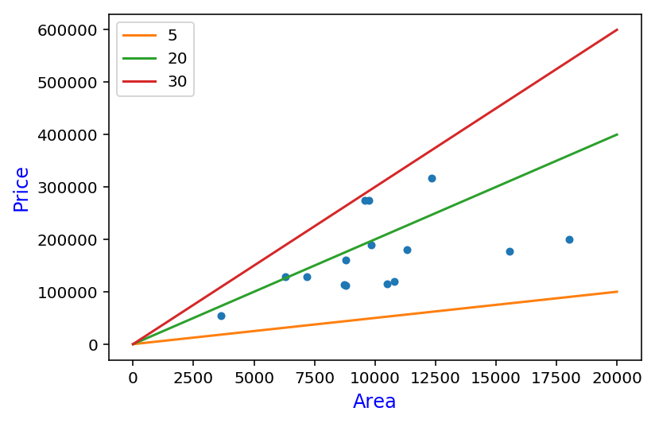

```python
# Check out our naive prediction line
plt.plot(sample_data['LotArea'], sample_data['SalePrice'], '.', markersize=8, label='_nolegend_')
plt.xlabel('Area', fontsize=12, color='blue')
plt.ylabel('Price', fontsize=12, color='blue')
graph('5*x', range(0, 20000))
graph('20*x', range(0, 20000))
graph('30*x', range(0, 20000))
plt.legend(['5', '20', '30'])
```